# Análise de Gastos de Deputados

Paulo Vinicius Soares

25 de outubro de 2017

```r
library(readr)
library(knitr)
library(tidyverse)
```

# Introdução

Esta análise será feita utilizando os dados de gastos da *Cota Parlamentar* dos deputados dos anos de 2015, 2016 e 2017. Abaixo temos 5 perguntas que iremos responder a partir dos nossos dados.

Antes, iremos importar a nossa base de dados.

```r
dadosCEAP <- read_csv(unz("../database/dadosCEAP.csv.zip", "dadosCEAP.csv")) %>%
  mutate(diaMesAno = as.Date(stringr::str_sub(dataEmissao, 1, 10)))

dadosCEAP$valorGlosa <- as.numeric(sub(",", ".", dadosCEAP$valorGlosa, fixed = TRUE))
limiteMensalCEAP <- read_csv("../database/limiteMensalCEAP.csv")
```

# Perguntas

## 1. Quais os partidos que mais fazem uso da CEAP? Quais os partidos que menos fazem uso? Mesmas perguntas considerando valores em R$.

Abaixo temos um gráfico dos partidos por uso da CEAP.

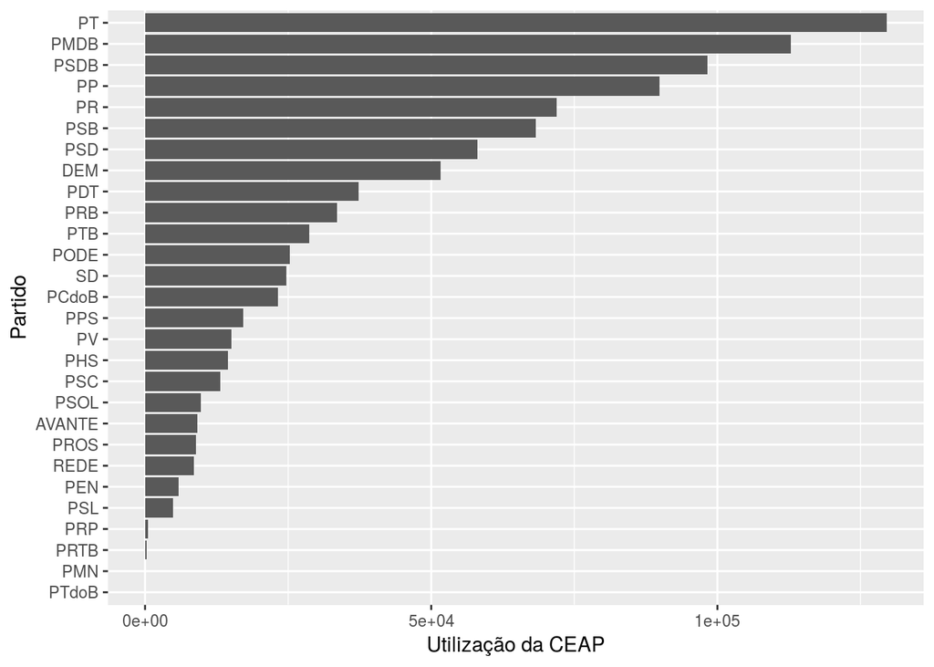

```r
dadosCEAP %>%
  filter(!sgPartido %in% NA) %>%
  group_by(sgPartido) %>%
  summarise(n = n()) %>%
  ggplot(aes(x = reorder(sgPartido, n), y = n)) +
  xlab("Partido") +
  ylab("Utilização da CEAP") +
  geom_bar(stat = "identity") +
  coord_flip()
```

Analisando o gráfico acima temos que os maiores gastos advém do PT, PMDB e PSDB. Temos que considerar também o número de deputados que cada partido possui. Esses três partidos possuem um número muito maior de deputados em relação aos demais partidos.

Analisando agora o gráfico dos gastos dos partidos por uso da CEAP, temos:

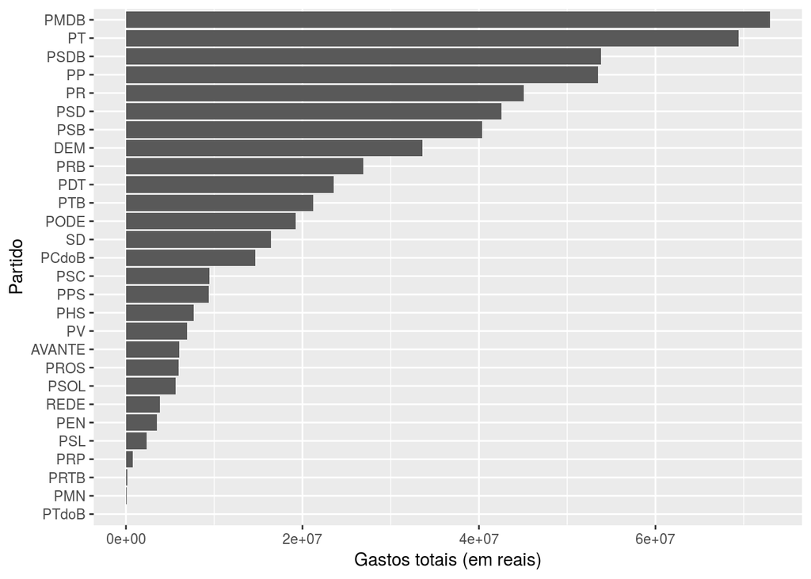

```r
dadosCEAP %>%
  filter(!sgPartido %in% NA) %>%
  group_by(sgPartido) %>%
  summarise(valorGastos = sum(valorDocumento)) %>%
  ggplot(aes(x = reorder(sgPartido, valorGastos), y = valorGastos)) +
  xlab("Partido") +
  ylab("Gastos totais (em reais)") +
  geom_bar(stat="identity") +
  coord_flip()
```

O partido que mais gastou com a CEAP foi o PMDB, seguido pelo PT e seguido pelo PSDB e PP com uma diferença muito ínfima entre os dois.

Podemos analisar a distribuição através de um *boxplot* dos partidos:

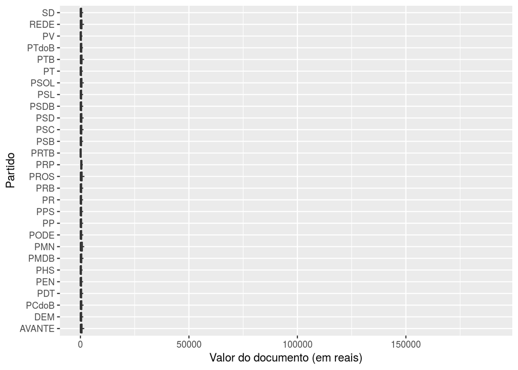

```r
gastos_partido <- dadosCEAP %>%
  filter(valorDocumento > 0 & !sgPartido %in% NA) %>%
  ggplot(aes(x = sgPartido, y = valorDocumento)) +
  xlab("Partido") +
  ylab("Valor do documento (em reais)") +
  geom_boxplot(outlier.alpha = 0) +
  coord_flip()

gastos_partido
```

Os dados estão muito concentrados em valores próximos à 0, por isso não é possível determinar com precisão a distribuição. Por essa razão, vamos determinar uma faixa de valores para melhorar a nossa visualização:

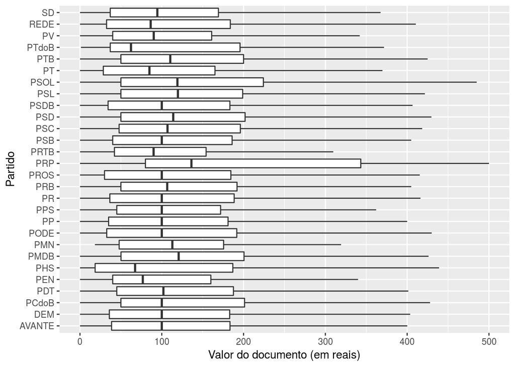

```r
gastos_partido +
  scale_y_continuous(limits = c(0, 500))
```

Podemos perceber que os valores tendem a estar entre 0 e 200 reais, com algumas exceções de distribuições com maior variação, tais como ocorre no *PRP*. A mediana dos valores é aproximadamente 100 reais.

## 2. Quais os tipos de despesa mais comuns no uso da CEAP? Mesma pergunta considerando valores em R$.

Analisando agora o gráfico dos tipos de despesa da CEAP por utilização, temos:

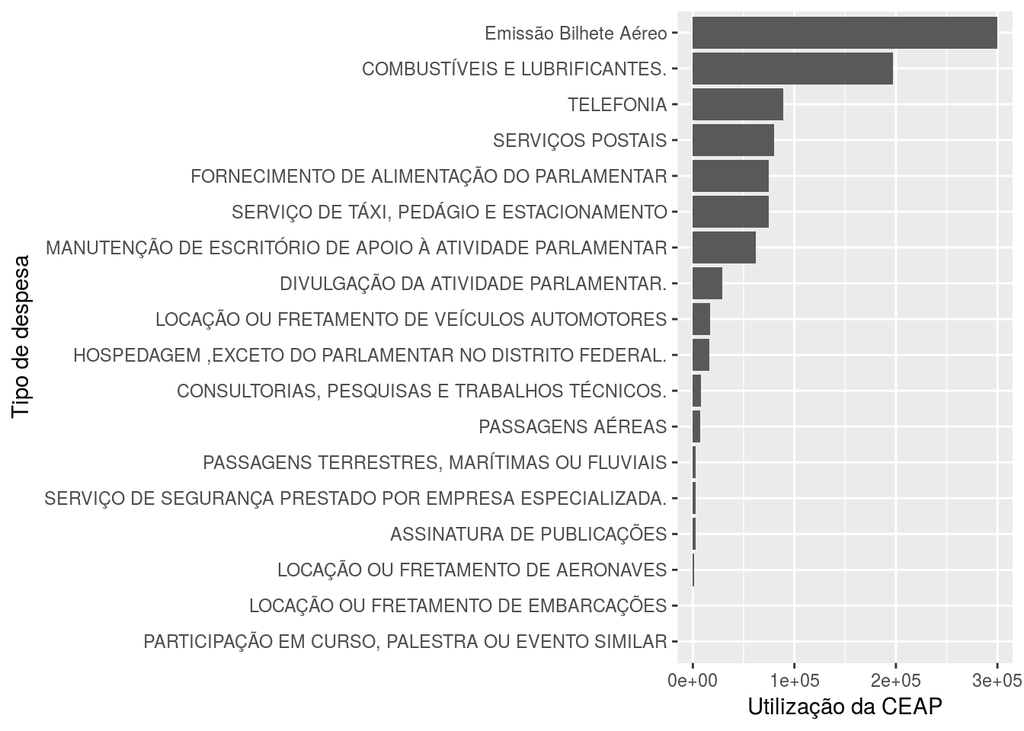

```r
dadosCEAP %>%
  group_by(tipoDespesa) %>%
  summarise(n = n()) %>%
  ggplot(aes(x = reorder(tipoDespesa, n), y = n)) +
  xlab("Tipo de despesa") +
  ylab("Utilização da CEAP") +
  geom_bar(stat = "identity") +
  coord_flip()
```

A emissão de bilhete aéreo é o grande responsável pelos gastos dos deputados, seguidos de combustíveis e lubrificante. Essa medida se dá em valor absoluto das solicitações de uso da CEAP.

Analisando agora o gráfico dos tipos de despesa da CEAP pelo valor dos gastos, temos:

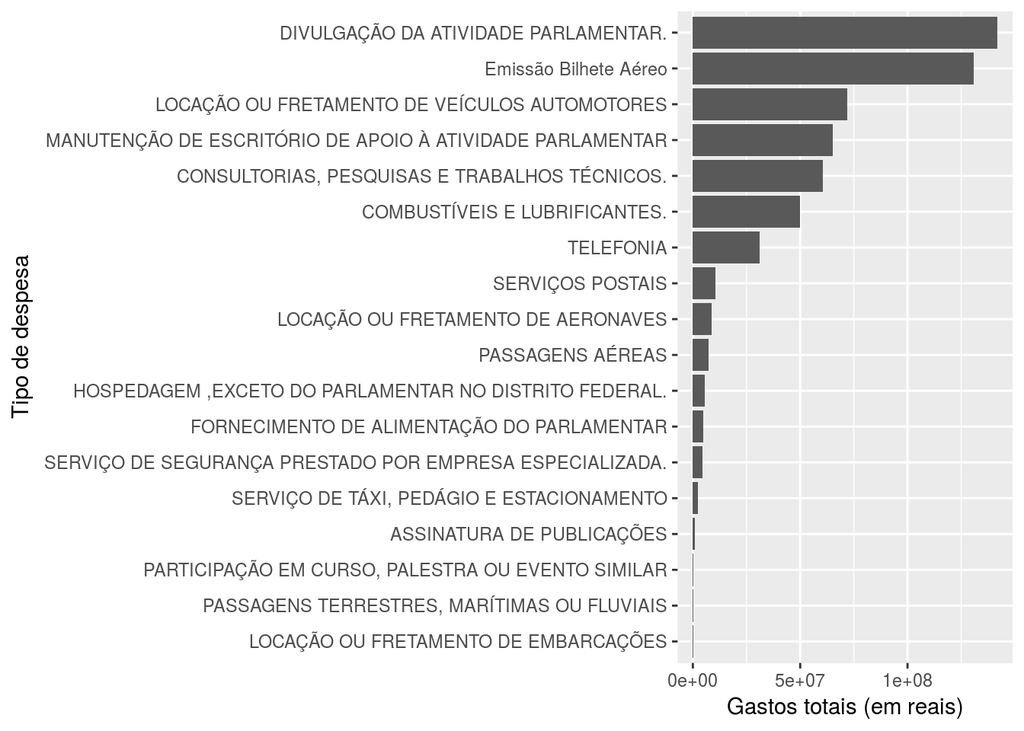

```r
dadosCEAP %>%
  group_by(tipoDespesa) %>%
  summarise(valorGastos = sum(valorDocumento)) %>%
  ggplot(aes(x = reorder(tipoDespesa, valorGastos), y = valorGastos)) +
  xlab("Tipo de despesa") +
  ylab("Gastos totais (em reais)") +
  geom_bar(stat = "identity") +
  coord_flip()
```

A divulgação da atividade parlamentar é a maior responsável pelos gastos na CEAP, seguida pela emissão de bilhete aéreo.

Se dermos uma olhada na distribuição dos gastos através de um *boxplot*, temos:

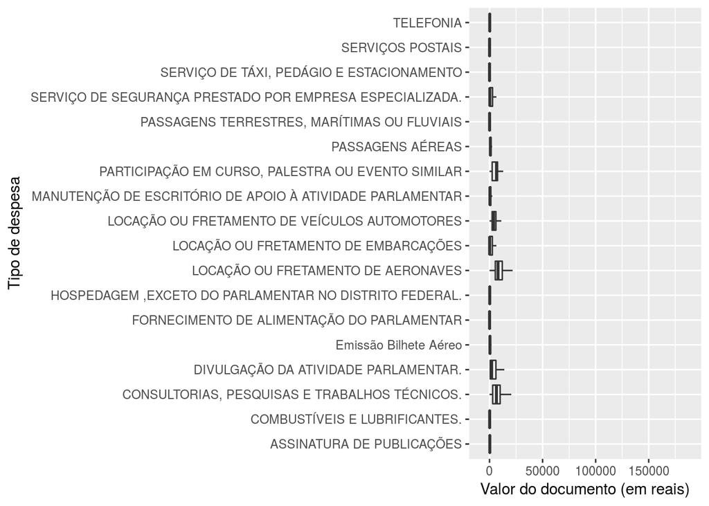

```r
tipos_gastos <- dadosCEAP %>%
  ggplot(aes(x = tipoDespesa, y = valorDocumento)) +
  xlab("Tipo de despesa") +
  ylab("Valor do documento (em reais)") +
  geom_boxplot(outlier.alpha = 0) +
  coord_flip()
tipos_gastos
```

Mais uma vez os valores estão muito concentrados em 0, de forma que precisamos delimitar o intervalo de exibição.

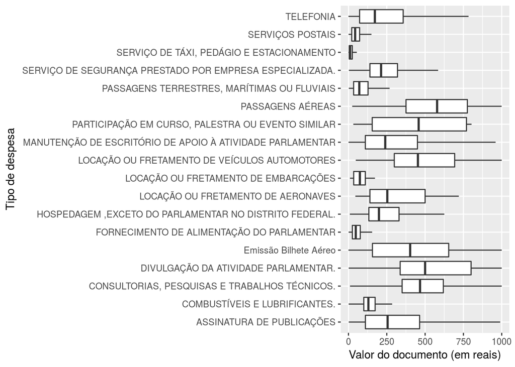

```r
tipos_gastos + scale_y_continuous(limits = c(0, 1000))
```

Participação em curso, palestra ou evento similar apresenta uma grande variação nos preços. Ou seja, os deputados participam de palestras que vão de 100 até 750 reais, geralmente.

## 3. Levando em conta o estado pelo qual o deputado se elegeu, quais os estados que mais fazem uso da CEAP? Quais os que menos fazem uso? Mesmas perguntas considerando gastos em R$.

Analisando agora o Gráfico de utilização por estado da CEAP, temos:

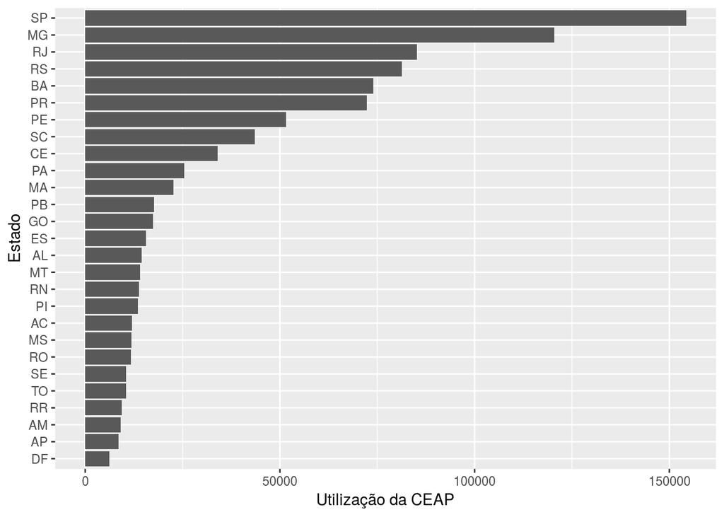

```r
dadosCEAP %>%
  filter(!sgUF %in% NA) %>%
  group_by(sgUF) %>%
  summarise(n = n()) %>%
  ggplot(aes(x = reorder(sgUF, n),y = n)) +
  xlab("Estado") +
  ylab("Utilização da CEAP") +
  geom_bar(stat = "identity") +
  coord_flip()
```

Pelo gráfico podemos perceber que SP possui o maior número de requisições da CEAP em valores absolutos dos dados analisados. Em segundo lugar, Minas Gerais. Os estados que fazem menos uso são Amapá, Amazonas e Roraima. O Distrito Federal aparece em último, mas não é considerado estado.

Analisando agora o Gráfico dos gastos por estado da CEAP, temos:

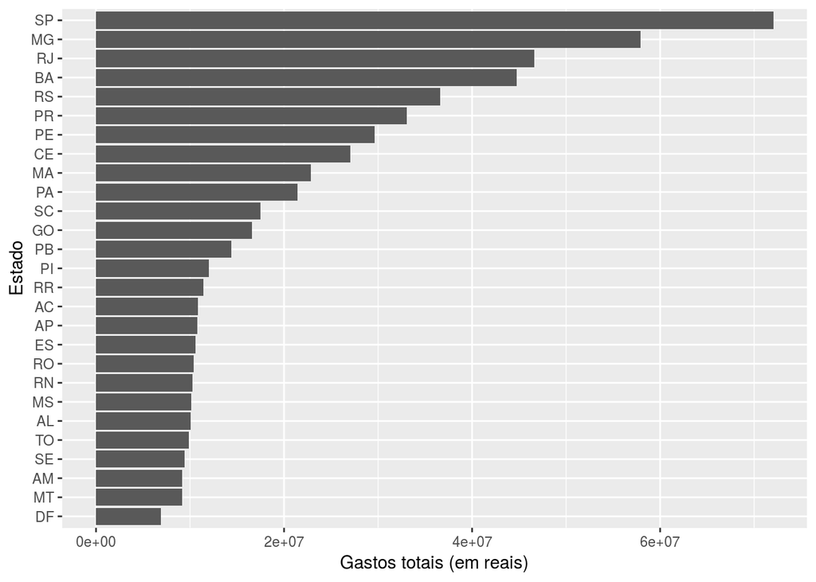

```r
dadosCEAP %>%
  filter(!sgUF %in% NA) %>%
  group_by(sgUF) %>%
  summarise(valorGastos = sum(valorLíquido)) %>%
  ggplot(aes(x = reorder(sgUF, valorGastos), y = valorGastos)) +
  xlab("Estado") +
  ylab("Gastos totais (em reais)") +
  geom_bar(stat="identity") +
  coord_flip()
```

São Paulo continua na liderança dos gastos seguido de Minas Gerais e Rio de Janeiro.

### Por que você acha isso?

Acredito que a quantidade de deputados de SP influencia nos gastos, pois o número de deputados por estado é equivalente à sua população. Dado isso, SP tem 70 deputados e por isso é o que possui mais gastos.

## 4. Quais os parlamentares que mais gastam com CEAP e quais os que menos gastam?

Separando os dados, temos:

```r
dados <- dadosCEAP %>%
  group_by(nomeParlamentar) %>%
  summarise(valorGastos = sum(valorLíquido))
```

*Plotando* os deputados que mais gastaram, temos:

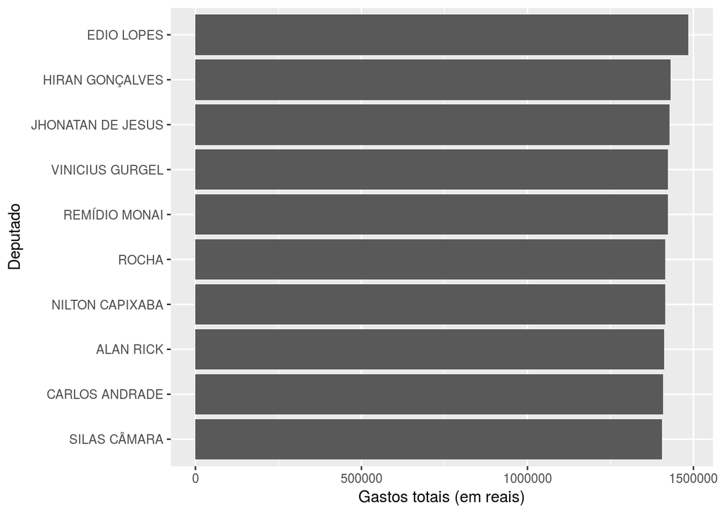

```r
# Os que mais gastaram
dados[order(-dados$valorGastos),] %>%
  head(10) %>%
  ggplot(aes(x = reorder(nomeParlamentar, valorGastos), y = valorGastos)) +
  xlab("Deputado") +
  ylab("Gastos totais (em reais)") +
  geom_bar(stat="identity") +
  coord_flip()
```

Os que menos gastaram, temos:

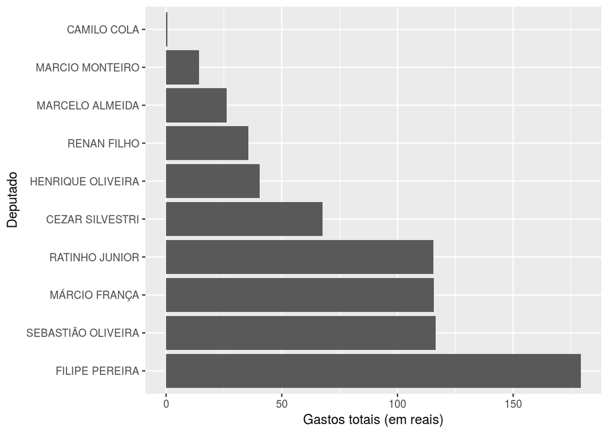

```r
# Os que menos gastaram
dados[order(dados$valorGastos),] %>%
  filter(valorGastos > 0) %>%
  head(10) %>%
  ggplot(aes(x = reorder(nomeParlamentar, -valorGastos), y = valorGastos)) +
  xlab("Deputado") +
  ylab("Gastos totais (em reais)") +
  geom_bar(stat="identity") +
  coord_flip()
```

Lembrando que essa análise foi feita considerando os valores absolutos, então podem existir deputados que ficaram pouco tempo na câmara enquanto outros estão lá até hoje e continuam se utilizando da CEAP.

## 5. Existe correlação entre a quantidade de gastos no exterior e o valor restituído da CEAP?

O valor restituído da CEAP é o valor líquido, que é repassado para o deputado após a comprovação da nota fiscal e do valor do documento ser conferido. Dessa forma, o valor é devolvido ao deputado e o gasto é contabilizado em sua cota parlamentar. Agora, verificaremos se há correlação entre o número de solicitações de uso da CEAP e o valor líquido.

```r
gastos_deputados_exterior <- dadosCEAP %>%
  filter(tipoDocumento==2) %>%
  group_by(nomeParlamentar) %>%
  summarise(numeroGastos = n())

gastos_deputados <- dadosCEAP %>%
  group_by(nomeParlamentar) %>%
  summarise(somaGastos = sum(valorLíquido))

gastos_deputados_exterior %>%
  left_join(gastos_deputados, by="nomeParlamentar") %>%
  select(somaGastos, numeroGastos) %>%
  cor() %>%
  kable()
```

|  | somaGastos | numeroGastos |
| --- | --- | --- |
| somaGastos | 1.0000000 | -0.0037931 |
| numeroGastos | -0.0037931 | 1.0000000 |

De acordo com o cálculo acima, não existe qualquer correlação entre as duas variáveis.

# Perguntas bônus

## Quais os estados cujos deputados gastam mais no exterior? Quais os estados cujos deputados gastam menos no exterior?

Através de vários gráficos podemos responder essa pergunta.

```r
# Quantidade
estados_custos_exterior <- dadosCEAP %>%
  group_by(tipoDocumento, sgUF) %>%
  filter(tipoDocumento==2) %>%
  summarise(n = n())

# Reais
estados_custos_reais_exterior <- dadosCEAP %>%
  filter(tipoDocumento==2) %>%
  group_by(sgUF) %>%
  summarise(gastos=sum(valorDocumento))
```

Quem mais solicitou a CEAP no exterior:

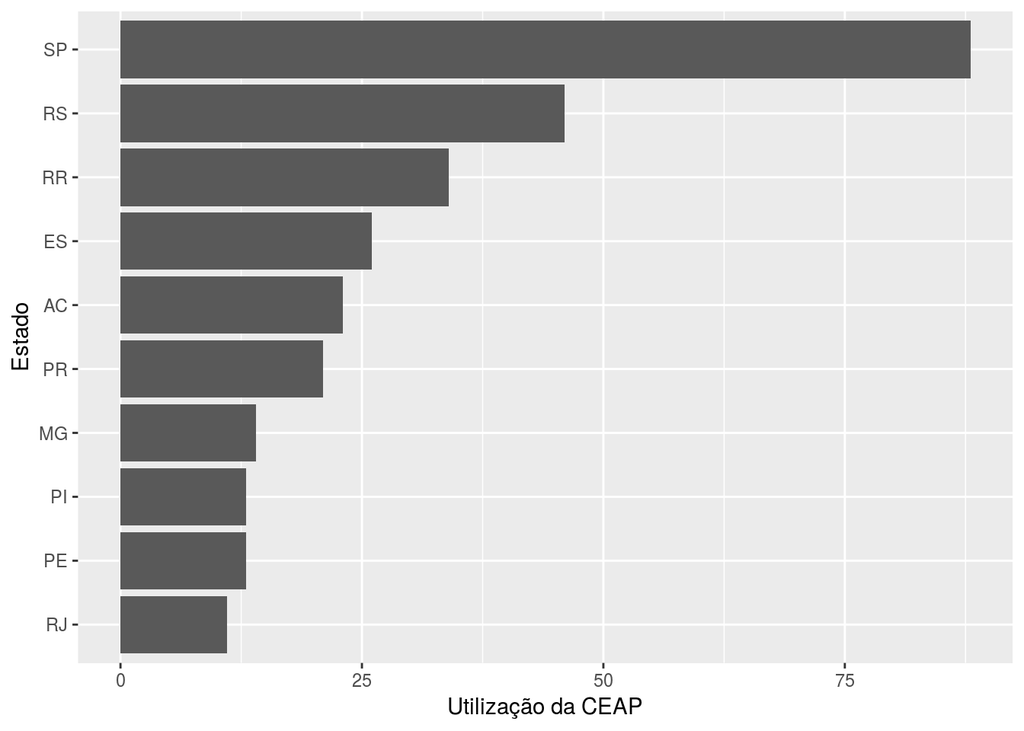

```r
# Quantidade (mais)
estados_custos_exterior[order(-estados_custos_exterior$n),] %>%
  head(10) %>%
  ggplot(aes(x = reorder(sgUF, n), y = n)) +
  xlab("Estado") +
  ylab("Utilização da CEAP") +
  geom_bar(stat="identity") +
  coord_flip()
```

Quem menos solicitou a CEAP no exterior:

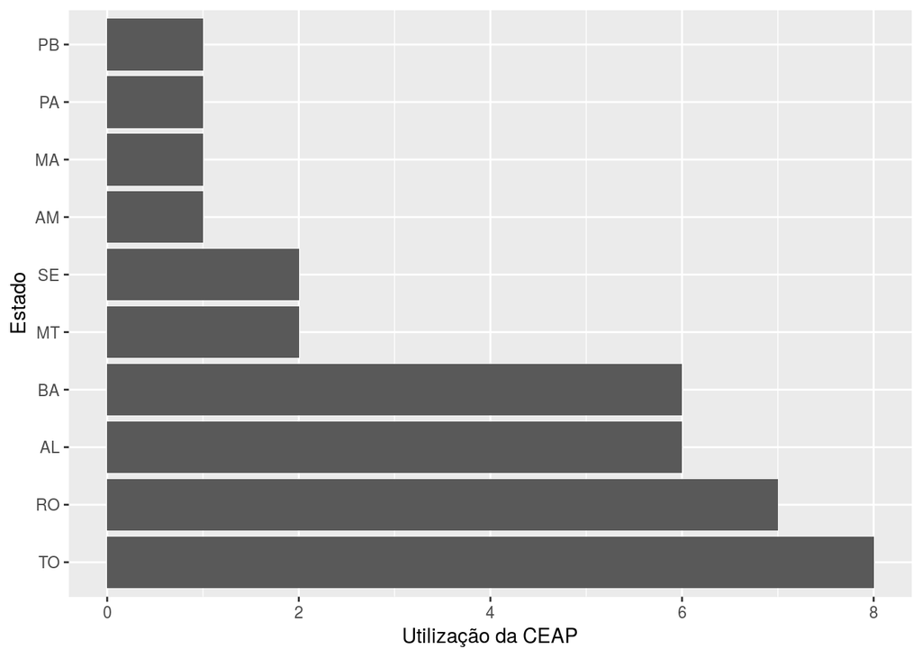

```r
# Quantidade (menos)
estados_custos_exterior[order(estados_custos_exterior$n),] %>%
  head(10) %>%
  ggplot(aes(x = reorder(sgUF, -n), y = n)) +
  xlab("Estado") +
  ylab("Utilização da CEAP") +
  geom_bar(stat="identity") +
  coord_flip()
```

Quem gastou mais com CEAP:

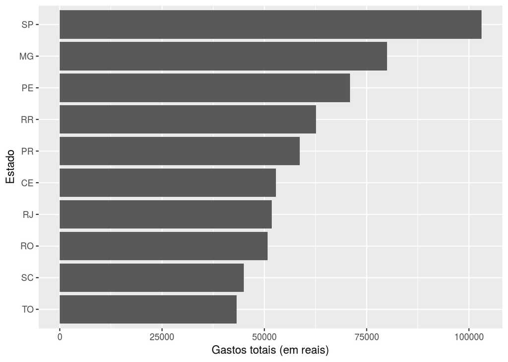

```r
# Reais (mais)
estados_custos_reais_exterior[order(-estados_custos_reais_exterior$gastos),] %>%
  head(10) %>%
  ggplot(aes(x = reorder(sgUF, gastos), y = gastos)) +
  xlab("Estado") +
  ylab("Gastos totais (em reais)") +
  geom_bar(stat="identity") +
  coord_flip()
```

Quem gastou menos com CEAP:

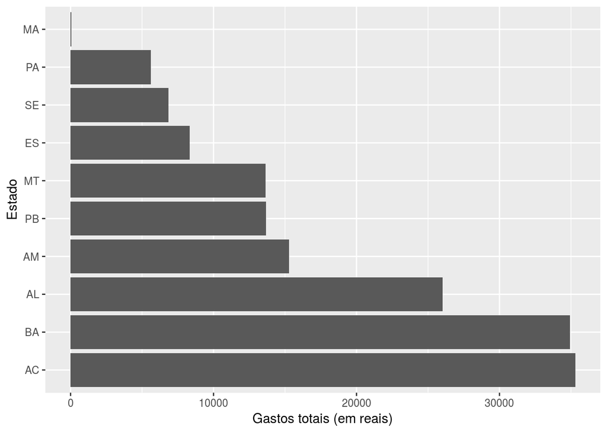

```r
# Reais (menos)
estados_custos_reais_exterior[order(estados_custos_reais_exterior$gastos),] %>%
  head(10) %>%
  ggplot(aes(x = reorder(sgUF, -gastos), y = gastos)) +
  xlab("Estado") +
  ylab("Gastos totais (em reais)") +
  geom_bar(stat="identity") +
  coord_flip()
```